# Recent Spain population trends

PLR

2026-04-18

## Latest date this report was produced

Today’s date is **18 April 2026**. This report was published on the week starting on **16 April 2026**.

## 1. Load Spain population data

We load latest Spanish Population Figures released by the Spanish National Institute: https://www.ine.es/consul/serie.do?d=true&s=ECP320

In the third tab from Excel file **“INE total and foreign population figures Spain.xlsx”** we load the table describing Total, foreign and nationals population figures in Spain, based on Spanish nationality for the 2004 2025 period.

## 2. Cleanse Spain populations figures data

From the newly on boarded data, we create a new Year variable from initial date column. As we only want to display Year values.

```
## # A tibble: 22 × 4
##    Year  total_population foreign_population Spanish_nationals
##    <chr>            <dbl>              <dbl>             <dbl>
##  1 2004          42547454                 NA                NA
##  2 2005          43296335            3430204          39866131
##  3 2006          44009969            3930916          40079053
##  4 2007          44784659            4449434          40335225
##  5 2008          45668938            5086295          40582643
##  6 2009          46239271            5386659          40852612
##  7 2010          46486621            5402579          41084042
##  8 2011          46667175            5312440          41354735
##  9 2012          46818216            5236030          41582186
## 10 2013          46712650            5064584          41648066
## # ℹ 12 more rows
```

Then this is the foreign population in Spain for the same time period.

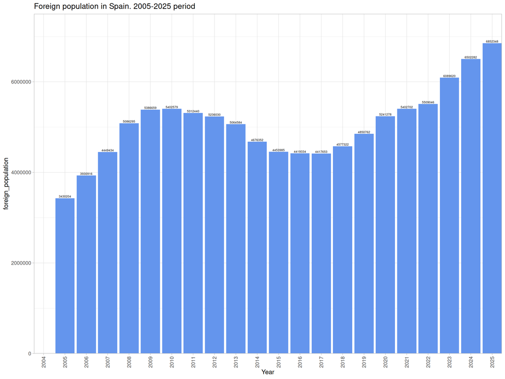

```r
options(scipen=999)

Spain_foreign_population <- INE_calc_fields %>%
                            ggplot(aes(x= Year, y = foreign_population)) +
  geom_bar(stat = "identity", fill = "cornflowerblue") +
  labs(title = "Foreign population in Spain. 2005-2025 period",
       substile = "Source: INE Spanish Office for National Statistics") +
  theme_light() +
  theme(axis.text.x = element_text(angle = + 90, hjust = 0.5, vjust = 0.5)) +
  geom_text(aes(label = foreign_population),size = 1.8,position = position_dodge(width = 0.2),vjust = -0.30,hjust = 0.50) +
  coord_cartesian( ylim=c(0,7500000), expand = FALSE )

Spain_foreign_population
```

This last plot displays national population in Spain for the 2005-2025 period

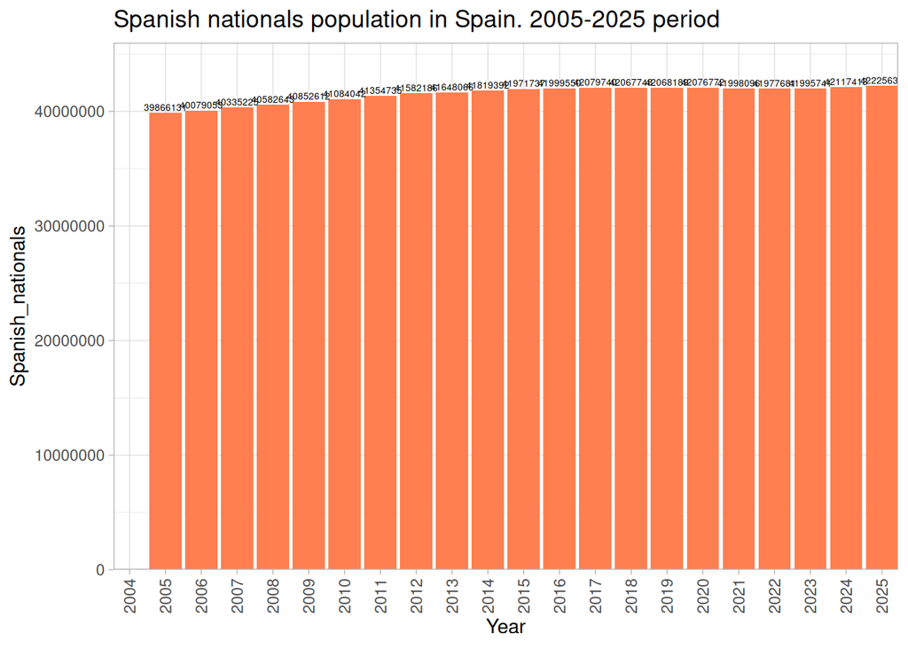

```r
options(scipen=999)

national_population_plot <- INE_calc_fields %>%
                            ggplot(aes(x= Year, y = Spanish_nationals)) +
  geom_bar(stat = "identity", fill = "coral") +
  labs(title = "Spanish nationals population in Spain. 2005-2025 period",
       substile = "Source: INE Spanish Office for National Statistics") +
  theme_light() +
  theme(axis.text.x = element_text(angle = + 90, hjust = 0.5, vjust = 0.5)) +
  geom_text(aes(label = Spanish_nationals),size = 1.8,position = position_dodge(width = 0.2),vjust = -0.30,hjust = 0.50) +
  coord_cartesian( ylim=c(0,46000000), expand = FALSE )

national_population_plot
```

## 3. Spain population figures Overveiw details

In this section we highlight a couple of trends observed in both Total and foreign population in Spain from 2004 until 2025 period.

- As of 1st of January **2025**., the year for the latest available population figures, Total population in Spain was **49,077,984**. Up by 458,253 from previous year.
- In contrast, on the year **2004**, the first year on this series, total population in Spain was **42,547,454**.
- In terms of foreign population, on the following year **2005**.there was a foreign population of **3,430,204**
- At the end of the series on 1st January **2025**, latest foreign population figures in Spain was **6,852,348**. We will describe these population changes in absolute figures and percent change in the next section below.

## 4. Year on year increase in total and forein population in Spain

In this section we will include several calculations to describe the year on year change in Total, national and foreign population in Spain. And also we will include population change for the entire period considered 2004-2025.